# Drivers of Change in Soil Organic Matter Stocks - Loss & Gains

Kristy Lam

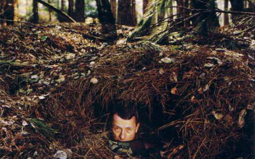

Late soil ecologist Jenny Hans under Spodosol leaf litter from [University of Maryland](https://extension.umd.edu/learn/soil-organic-matter)

# Understanding SOM

In order to understand SOM, one needs to move away from the traditional “humification” model and instead think of SOM as a continuum of progressively decomposing organic compounds as well as microbial-synthesized substances (see JW-1). OM does not persist because of its intrinsic properties, rather it is the physicochemical and biological influences from the surrounding environment that reduce the probability and rate of decomposition. Thus, long-term, in situ studies of entire soil profiles are necessary to investigate distinct mechanisms underpinning soil carbon sequestration. Schmidt et al. (2011) studied the persistence of SOM as an ecosystem property and identified eight recent insights into carbon cycling in soils. Table 1 lists these insights and their recommendations on how to improve current ecosystem models.

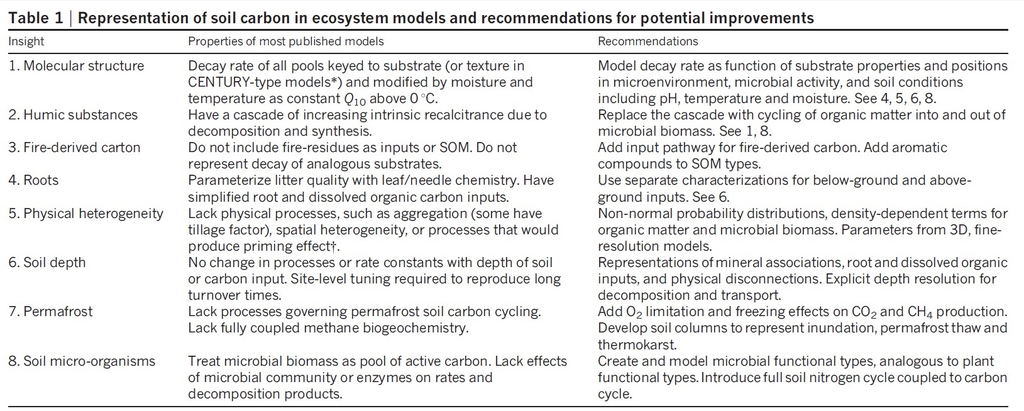

From Schmidt et al. (2011) DOI: [10.1038/nature10386](https://www-nature-com.eres.library.manoa.hawaii.edu/articles/nature10386)

Sources:  
Lehmann and Kleber (2015) DOI: 10.1038/nature16069  
Hubanks et al. - in press  
Schmidt et al. (2011) DOI: [10.1038/nature10386](https://www-nature-com.eres.library.manoa.hawaii.edu/articles/nature10386)

# SOM dynamics - drivers of change

As a soil ecosystem ages, the soil C stock begins to approach its carrying capacity (Figure 1). Initially, soil C declines because dead organic matter is decomposed faster than plant biomass accumulates. Later in the cycle, dead organic matter stocks start to increase and accumulate. Then, the soil reaches the maximum rate of net carbon uptake before reaching its carrying capacity of soil C.

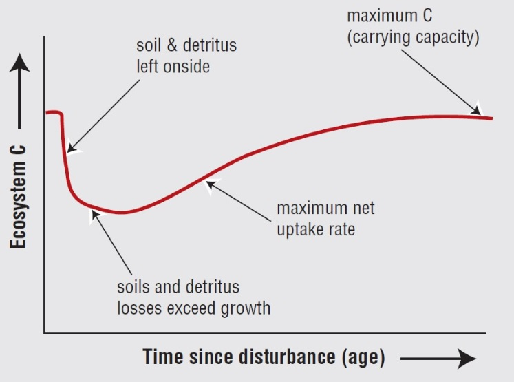

Figure 1. Net changes in ecosystem C stocks over time from IPCC

Over time and space, SOM content can change through natural (biotic and abiotic) or anthropogenic influences as well. Many factors, such as hydrology, can result in both SOM loss or gain via erosion or deposition, respectively. Figure 2 lists several key factors contributing to SOM dynamics. This list is not exhaustive; more studies need to be conducted to properly understand the mechanisms driving SOM dynamics. Various case studies have looked at specific components or influences resulting in SOM gain or loss (Table 2).

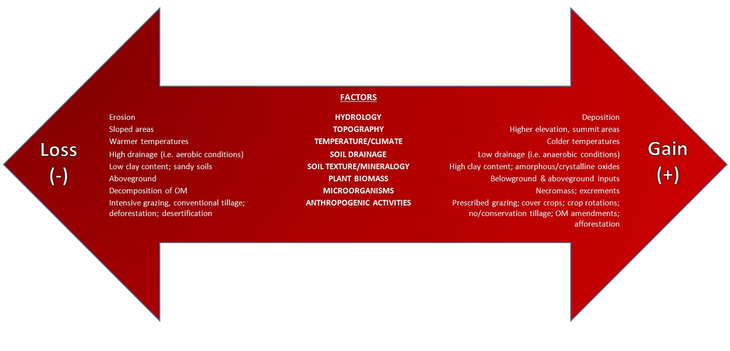

Figure 2. Factors that drive SOM dynamics

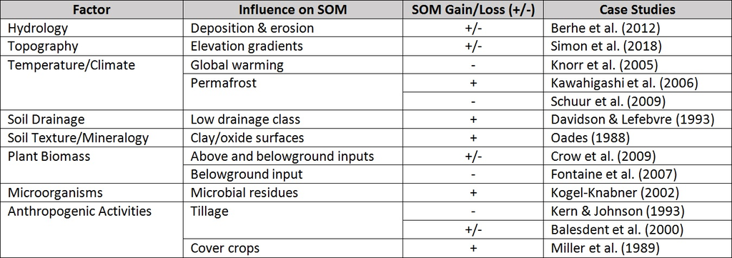

Table 2. Overview of factors that drive SOM dynamics and their supporting case studies

Sources:  
Schmidt et al. (2011) DOI: [10.1038/nature10386](https://www-nature-com.eres.library.manoa.hawaii.edu/articles/nature10386)]  
Wills et al. (2013) DOI: [10.2136/sssaj2012.0168](https://www.soils.org/publications/sssaj/abstracts/77/5/1711)]  
USDA “Grazing Management and Soil Health” (2016) from NRCS  
“Climate Change 2001: Mitigation” Report from IPCC

# Current Initiatives

**Global Soil Organic Carbon (GSOC) Map**

The Global Soil Information System (GLOSIS), created by the Food and Agriculture Organization (FAO), has also developed a map showing C stock around the world - see map [here](http://54.229.242.119/apps/GSOCmap.html).

**Coordination of International Research Cooperation on soil Carbon Sequestration in Agriculture (CIRCASA) Project** CIRCASA is a European Union (EU) group that aims to develop international synergies concerning research and knowledge exchange in the field of carbon sequestration in agricultural soils at both EU and global levels.  
Visit this [website](https://www.circasa-project.eu/About-us)

**The Transboundary Agro-ecosystem Management Project for the Kagera River Basin (Kagera TAMP)** In Africa, efforts are being made to adopt an integrated ecosystems approach for the management of land resources in the Kagera Basin generate local, national, and global benefits. Watch this [video](https://www.youtube.com/watch?v=_c2tZ6mznvI).